# PEC2 Análisis de Datos Ómicos

Rita Ortega Vallbona

12 de junio, 2020

Todos los archivos relacionados con este trabajo se pueden encontrar en el repositorio de Github [riorval/ADO_PEC2](https://github.com/riorval/ADO_PEC2.git).

# 1 Abstract

# 2 Objetivos

# 3 Materiales y métodos

## 3.1 Los Datos

Los datos proporcionados en el enunciado provienen del repositorio GTEx (*Genotype-Tissue Expression*), que recoge información de expresión específica de 54 tipos de tejido sano, proveniente de 1000 individuos (“GTEx Portal,” n.d.). Este [**portal**](https://www.gtexportal.org/home/) permite el acceso a los datos de expresión, imágenes de histología, etc.

Obtenemos los datos de targets y counts de los archivos csv proporcionados en el enunciado: targets.csv y counts.csv.

Estos son datos de expresión (RNA-seq) pertenecientes a un análisis del tiroides, donde se comparan tres tipos de infiltración en 292 muestras:

- *Not infiltrated tissues* (**NIT**): 236 muestras
- *Small focal infiltrates* (**SFI**): 42 muestras
- *Extensive lymphoid infiltrates* (**ELI**): 14 muestras

Con este script extraemos 10 muestras de cada grupo del archivo targets.csv y subseteamos las columnas escogidas en el archivo counts.csv:

```r
> # Separamos el dataframe que recoge los targets por grupos
> NIT <- subset(all_targets, Group == "NIT")
> SFI <- subset(all_targets, Group == "SFI")
> ELI <- subset(all_targets, Group == "ELI")
>
> # Seleccionamos 10 muestras de cada grupo y las unimos en un
> # único dataframe que recoge los targets con los que
> # trabajaremos
> set.seed(params$seed.extract)
> NIT10 <- NIT[sample(nrow(NIT), size = 10, replace = FALSE), ]
> SFI10 <- SFI[sample(nrow(SFI), size = 10, replace = FALSE), ]
> ELI10 <- ELI[sample(nrow(ELI), size = 10, replace = FALSE), ]
>
> mytargets <- rbind(NIT10, SFI10, ELI10, deparse.level = 0)
>
> # Extraemos los nombres de las muestras y cambiamos los
> # guiones por puntos para que coincidan con los nombres de
> # las muestras en el dataframe de counts
> sample_names <- mytargets[, 3]
> s_names <- gsub("-", ".", sample_names)
>
> # Subseteamos las columans escogidas del dataframe de counts
> mycounts <- dplyr::select(all_counts, s_names)
> row.names(mycounts) <- all_counts$X
```

De este modo hemos obtenido dos datasets: `mytargets` que recoge los detalles de cada una de las 30 muestras con las que vamos a trabajar, y `mycounts`, que representa la tabla de contajes de estas 30 muestras.

## 3.2 Preprocesado de los datos

Para poder identificar los tipos de muestra con mayor facilidad, procedemos a renombrar las columnas de `mycounts` con nombres cortos indicativos de a qué grupo pertenecen, y también lo asignamos a `mytargets`.

```r
> newShortNames <- c(paste0("NIT", 1:10), paste0("SFI", 1:10),
+     paste0("ELI", 1:10))
> mytargets <- cbind(mytargets, newShortNames)
>
> # Asignamos los nuevos nombres cortos a las columnas de
> # mycounts
> colnames(mycounts) <- mytargets$newShortNames
```

De este modo, nuestros datos de contaje quedan así:

```r
> head(mycounts)
```

|  | NIT1 | NIT2 | NIT3 | NIT4 | NIT5 | NIT6 | NIT7 | NIT8 | NIT9 | NIT10 | SFI1 | SFI2 | SFI3 | SFI4 | SFI5 | SFI6 | SFI7 | SFI8 | SFI9 | SFI10 | ELI1 | ELI2 | ELI3 | ELI4 | ELI5 | ELI6 | ELI7 | ELI8 | ELI9 | … |
| --- | --- | --- | --- | --- | --- | --- | --- | --- | --- | --- | --- | --- | --- | --- | --- | --- | --- | --- | --- | --- | --- | --- | --- | --- | --- | --- | --- | --- | --- | --- |
| ENSG00000223972.4 | 1 | 0 | 2 | 1 | 2 | 0 | 4 | 4 | 5 | 3 | 5 | 3 | 2 | 7 | 1 | 8 | 1 | 0 | 2 | 3 | 3 | 3 | 5 | 4 | 1 | 0 | 0 | 6 | 1 | … |
| ENSG00000227232.4 | 584 | 1487 | 412 | 800 | 542 | 1325 | 513 | 852 | 1034 | 487 | 656 | 533 | 491 | 1000 | 483 | 548 | 1064 | 426 | 679 | 426 | 1301 | 979 | 489 | 1325 | 474 | 834 | 419 | 1003 | 775 | … |
| ENSG00000243485.2 | 0 | 1 | 0 | 2 | 1 | 2 | 9 | 4 | 5 | 1 | 1 | 1 | 2 | 2 | 0 | 11 | 2 | 3 | 2 | 1 | 1 | 3 | 1 | 1 | 1 | 1 | 0 | 1 | 2 | … |
| ENSG00000237613.2 | 0 | 0 | 1 | 2 | 0 | 0 | 10 | 4 | 5 | 2 | 1 | 0 | 0 | 5 | 0 | 6 | 0 | 4 | 4 | 1 | 0 | 2 | 3 | 0 | 0 | 1 | 1 | 2 | 0 | … |
| ENSG00000268020.2 | 0 | 0 | 0 | 0 | 0 | 0 | 3 | 1 | 0 | 0 | 0 | 0 | 0 | 3 | 0 | 1 | 2 | 1 | 0 | 1 | 0 | 5 | 2 | 2 | 1 | 0 | 0 | 0 | 0 | … |
| ENSG00000240361.1 | 1 | 2 | 0 | 1 | 0 | 0 | 4 | 3 | 3 | 0 | 1 | 0 | 0 | 5 | 0 | 4 | 2 | 1 | 1 | 2 | 1 | 8 | 1 | 1 | 1 | 0 | 0 | 1 | 0 | … |

Antes de proceder con el análisis de los datos, debemos evaluar la calidad de los datos crudos con los que vamos a trabajar, para detectar cualquier fallo técnico que pueda afectar a la interpretación de los datos. Analizaremos la calidad de los datos con representaciones gráficas, y dado que los datos resultantes de contajes suelen estar altamente sesgados, aplicaremos previamente una transformación logarítmica en base 2 para “normalizar” los datos. Además hemos de tener en cuenta que algunos de los contajes resultan en 0, para que ello no suponga un problema tomaremos *pseudocounts*, sumando una constante en todos los contajes, para que no den problema en la transformación logarítmica.

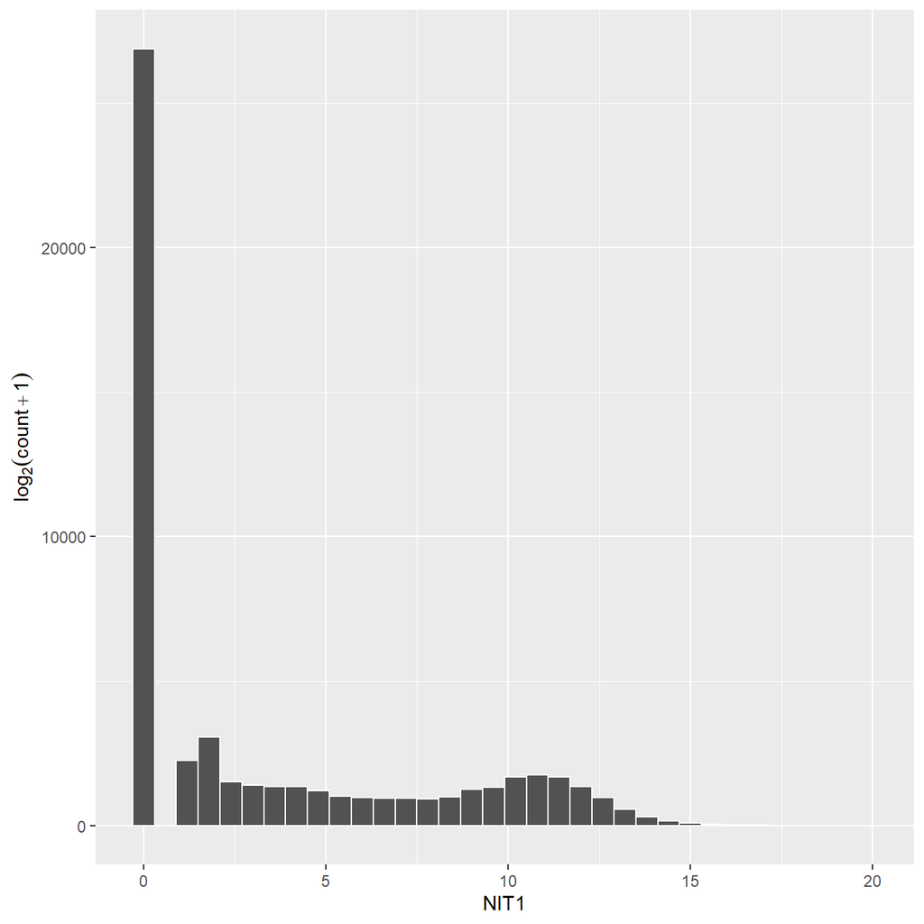

```r
> pseudoCounts <- log2(mycounts + 1)
>
> library(ggplot2)
>
> ggplot(pseudoCounts, aes(x = pseudoCounts[, 1])) + ylab(expression(log[2](count +
+     1))) + xlab(names(pseudoCounts)[1]) + geom_histogram(colour = "white",
+     fill = "#525252", binwidth = 0.6)
```

Esta transformación logarítmica podría no ser suficiente para evaluar realmente cómo se distribuyen los datos, ya que los datos procedentes de RNA-seq no son homocedásticos, sino que su varianza aumenta según aumenta la media. Intentamos utilizar una función especializada del paquete `edgeR` para hacer una transformación de los datos y comparamos los resultados:

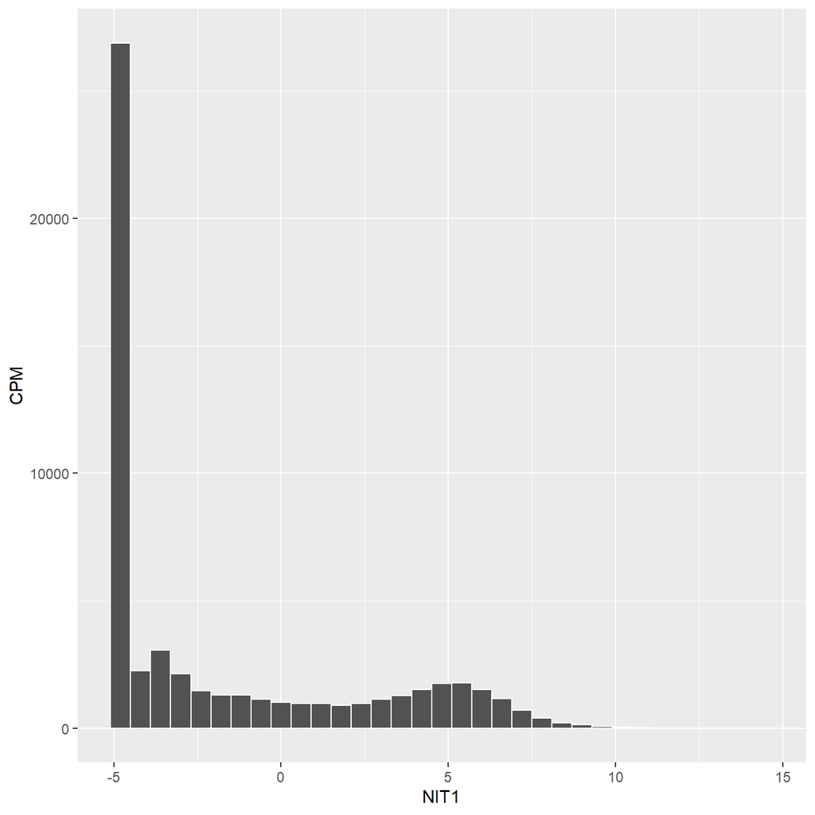

```r
> library(edgeR)
> pseudoCounts2 <- cpm(mycounts, prior.count = 2, log = TRUE)
>
> library(ggplot2)
> ggplot(pseudoCounts, aes(x = pseudoCounts2[, 1])) + ylab("CPM") +
+     xlab(names(mycounts)[1]) + geom_histogram(colour = "white",
+     fill = "#525252", binwidth = 0.6)
```

Para poder visualizar la distribución de los datos de las 30 muestras con las que trabajamos, las representamos en forma de boxplot:

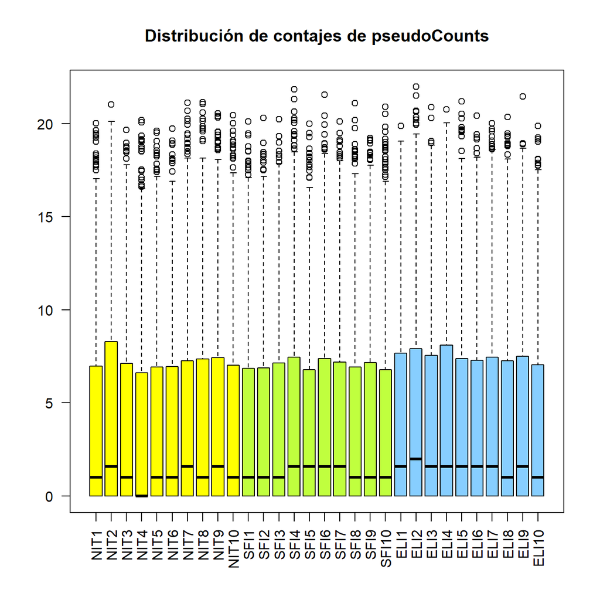

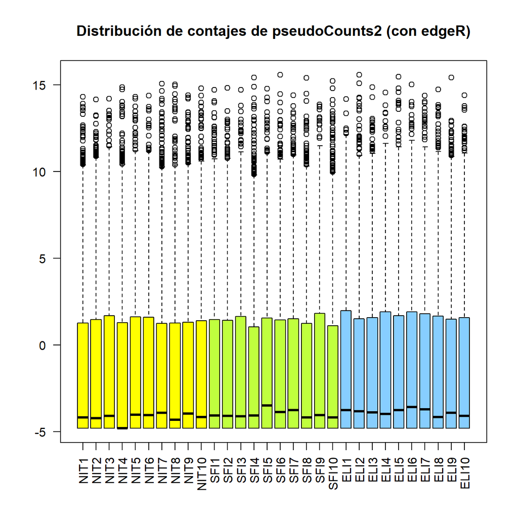

Representamos los datos en gráficos de densidades para detectar si pudiera haber modos secundarios de la distribución de los datos:

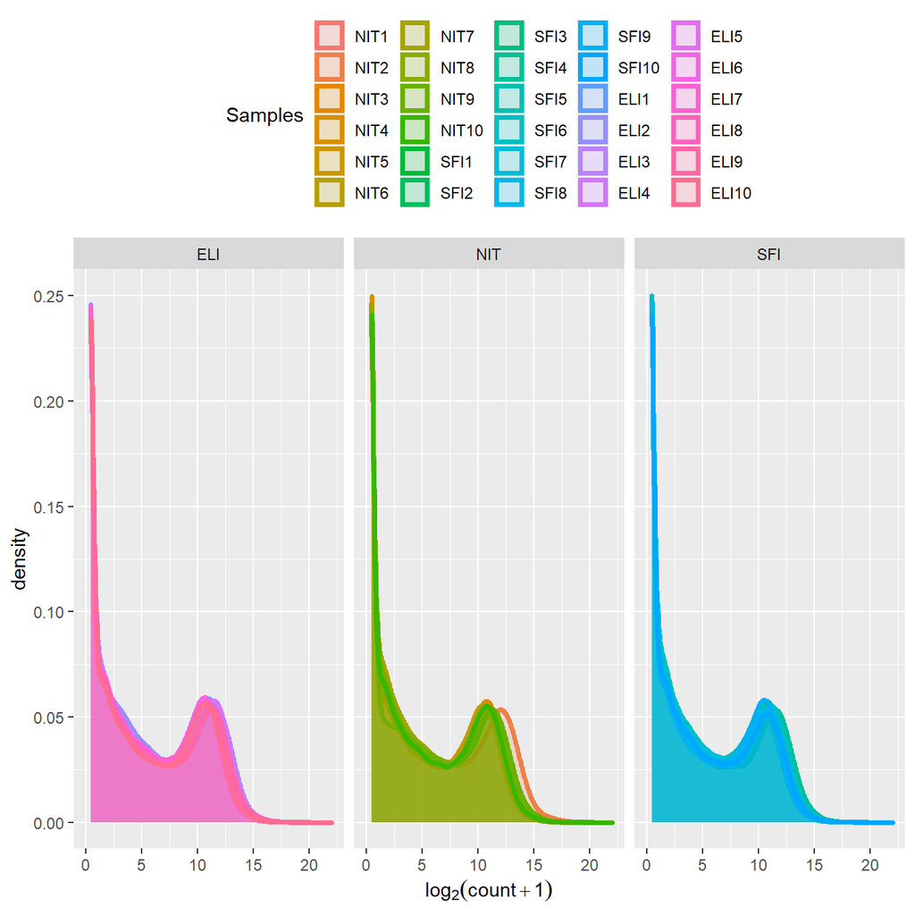

Gráficos de densidades que muestra las densidades empíricas de las muestras individuales dentro de cada una de las tres condiciones experimentales

Para comprobar la reproducibilidad de las muestras, representamos los MA-plots para comparar muestras entre sí:

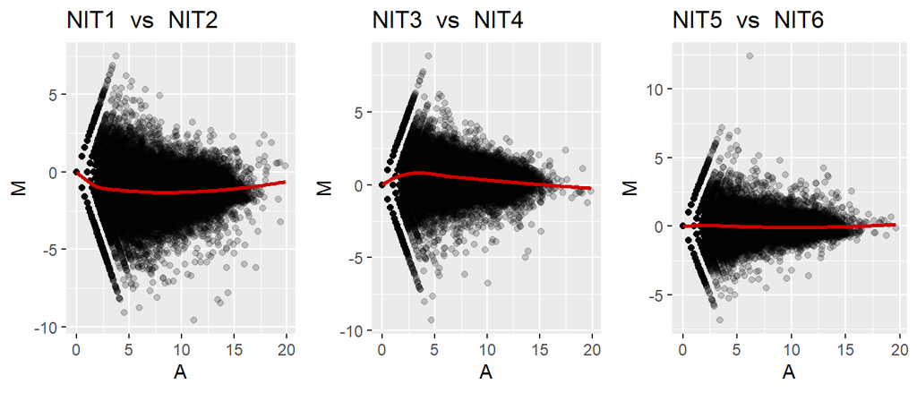

Representación MA de tres comparaciones entre muestras del grupo NIT

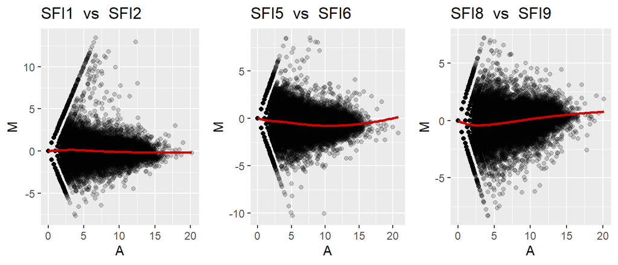

Representación MA de tres comparaciones entre muestras del grupo SFI

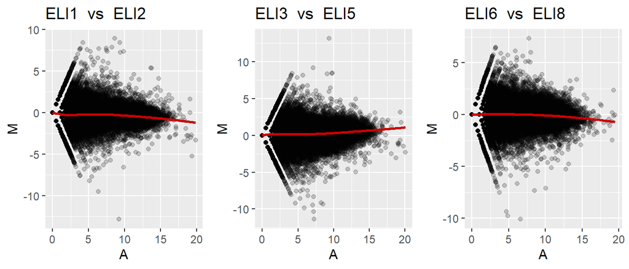

Representación MA de tres comparaciones entre muestras del grupo ELI

```r
> myMAplot <- function(dataset, numberX, numberY) {
+     data <- dataset
+
+     nameX <- names(data)[numberX]
+     nameY <- names(data)[numberY]
+
+     x <- data[, numberX]
+     y <- data[, numberY]
+
+     M = x - y
+     A = (x + y)/2
+
+     dfMA <- data.frame(A, M)
+
+     library(ggplot2)
+     ggplot(dfMA, aes(x = A, y = M)) + geom_point(size = 1.5,
+         alpha = 1/5) + stat_smooth(se = F, method = "loess",
+         color = "red3") + ggtitle(paste(nameX, " vs ", nameY))
+ }
```

Para ver qué muestras son más similares entre sí, las representamos en un heatmap:

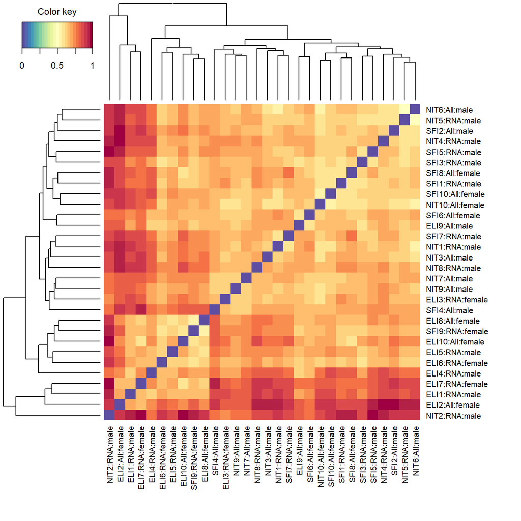

Mediante un análisis de componentes principales (PCA, *Principal Component Analysis*), podremos visualizar los efectos de las diferentes condiciones experimentales y detectar *batch effects*:

```r
> library(DESeq)
> grupo <- mytargets$Group
> datatype <- substr(mytargets$molecular_data_type, 1, 3)
> sexo <- mytargets$sex
> anot <- AnnotatedDataFrame(data = data.frame(grupo, datatype,
+     sexo, row.names = colnames(pseudoCounts)))
> exprSetpseudoCounts <- new("ExpressionSet", exprs = as.matrix(pseudoCounts),
+     phenoData = anot)
```

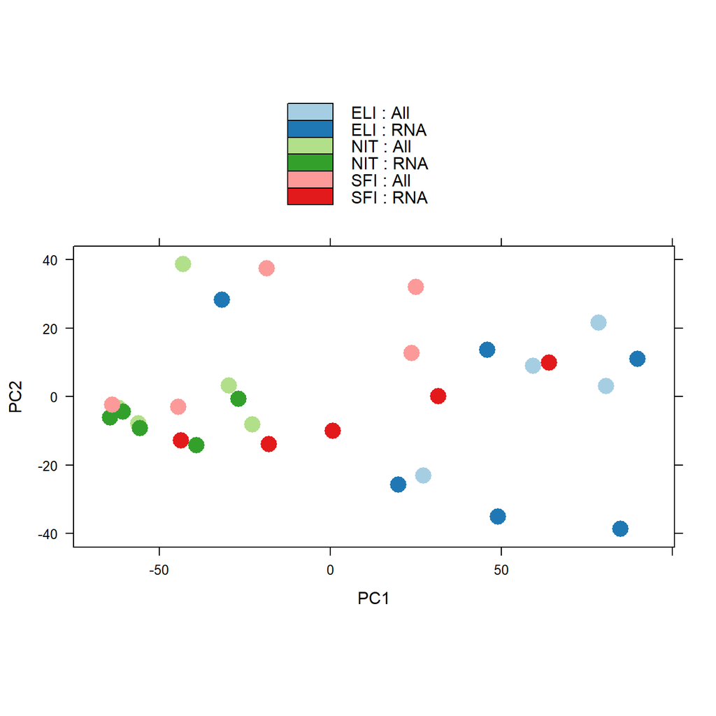

PCA teniendo en cuenta el grupo experimental y el tipo de datos

```r
> plotPCA(exprSetpseudoCounts, intgroup = c("grupo", "datatype"))
```

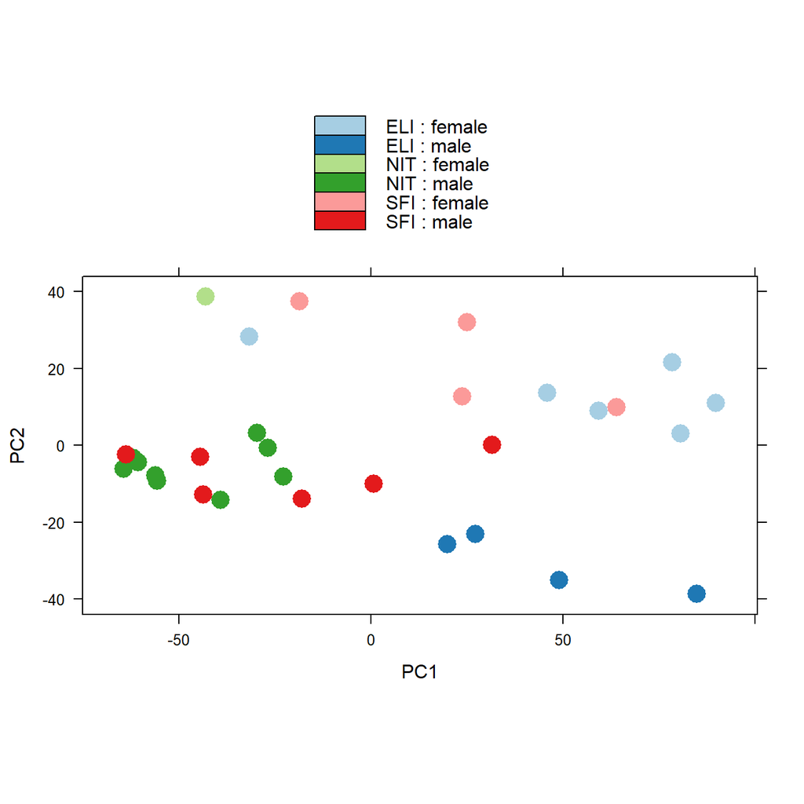

PCA teniendo en cuenta el grupo experimental y el sexo

```r
> plotPCA(exprSetpseudoCounts, intgroup = c("grupo", "sexo"))
```

### 3.2.1 Filtraje

Procedemos a realizar un filtraje de los genes que se ven menos expresados en todas las condiciones experimentales. Filtramos los genes que no se expresan en ninguna de las muestras, quedándonos con los que se expresan al menos en una muestra:

```r
> filtro1 <- rowSums(mycounts) > 0
> filtro1pseudoCounts <- pseudoCounts[filtro1, ]
> dim(mycounts)
```

```
[1] 56202    30
```

```r
> dim(filtro1pseudoCounts)
```

```
[1] 46229    30
```

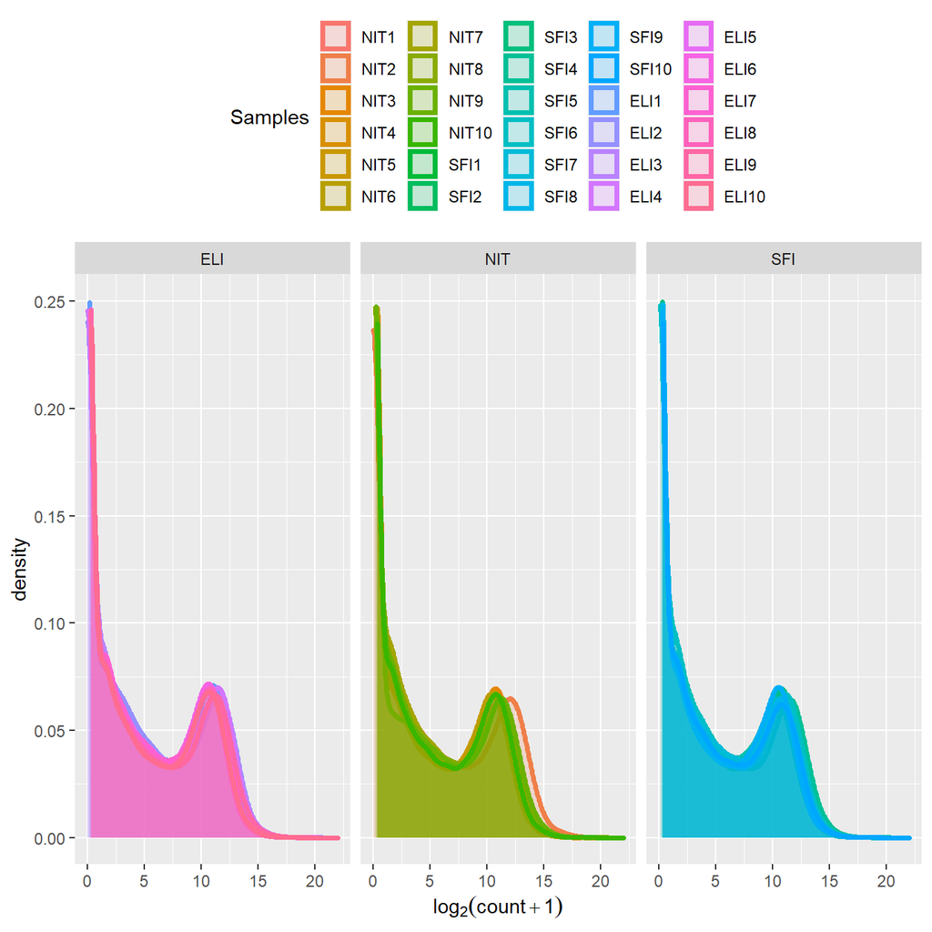

Diagramas de densidad de las muestras tras el filtrado de los genes que no se expresan

Para poder trabajar con mayor facilidad con los datos, los guardamos objeto tipo DGElist, con la función `DGEList` del paquete `edgeR`, que nos permite hacer el filtrado de los genes que no se expresan, tal y como hemos hecho con los *pseudocounts*, pero lo hacemos de los datos de counts sin la transformación previa que hicimos para facilitar la representación gráfica:

```r
> ConditionDGE <- mytargets$Group
> DGEFiltered <- edgeR::DGEList(counts = mycounts, group = factor(ConditionDGE),
+     remove.zeros = TRUE)
```

### 3.2.2 Normalización

Para normalizar nuestros datos, aplicaremos el método **TMM** (*Trimmed Mean of M-values*). Al aplicar el TMM, estamos asumiendo que la mayoría de los genes no están diferencialmente expresados. Diferentes autores defienden que este método de normalización es bastante efectivo para detectar genes diferencialmente expresados y para controlar los falsos positivos (Evans, Hardin, and Stoebel 2017). El método TMM tiene en cuenta que los pocos genes altamente expresados son los que más influyen en la expresión total, y que la probabilidad de que estos genes pueden estar diferencialmente expresados entre muestras en distintas condiciones, es igual que la probabilidad de que todos los genes lo estén, es decir, que exista una *expresión balanceada*. Para aplicar este método de normalización, utilizamos la función `calcNormFactors()` del paquete `edgeR`:

```r
> library(edgeR)
>
> DGEFiltered <- calcNormFactors(DGEFiltered, method = "TMM")
> dim(DGEFiltered$counts)
```

```
[1] 46229    30
```

Representamos los datos normalizados con el método MDS (*multidimensional scaling*):

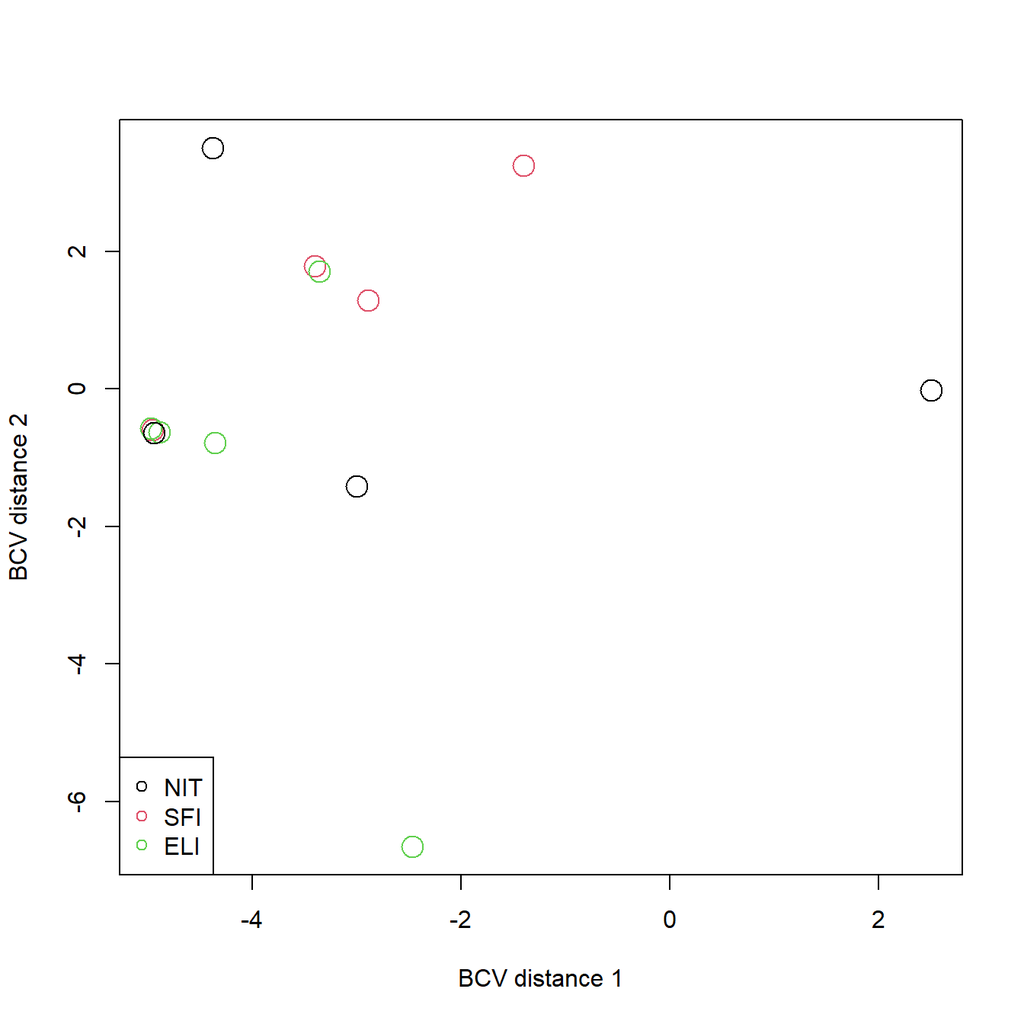

Representación de los datos normalizados con el método MDS

## 3.3 Identificación de genes diferencialmente expresados

Para identificar los genes diferencialmente expresados entre los diferentes grupos experimentales, primero debemos estimar el parámetro de dispersión, que nos indicará el grado de variación dentro de nuestro dataset.

```r
> DGEFiltered <- estimateCommonDisp(DGEFiltered, verbose = T)
```

```
Disp = 0.30317 , BCV = 0.5506
```

```r
> names(DGEFiltered)
```

```
[1] "counts"            "samples"           "common.dispersion"
[4] "pseudo.counts"     "pseudo.lib.size"   "AveLogCPM"
```

A partir de los parámetros de dispersión común calculamos las dispersiones *Tagwise*:

```r
> DGEFiltered <- estimateTagwiseDisp(DGEFiltered)
> names(DGEFiltered)
```

```
 [1] "counts"             "samples"            "common.dispersion"
 [4] "pseudo.counts"      "pseudo.lib.size"    "AveLogCPM"
 [7] "prior.df"           "prior.n"            "tagwise.dispersion"
[10] "span"
```

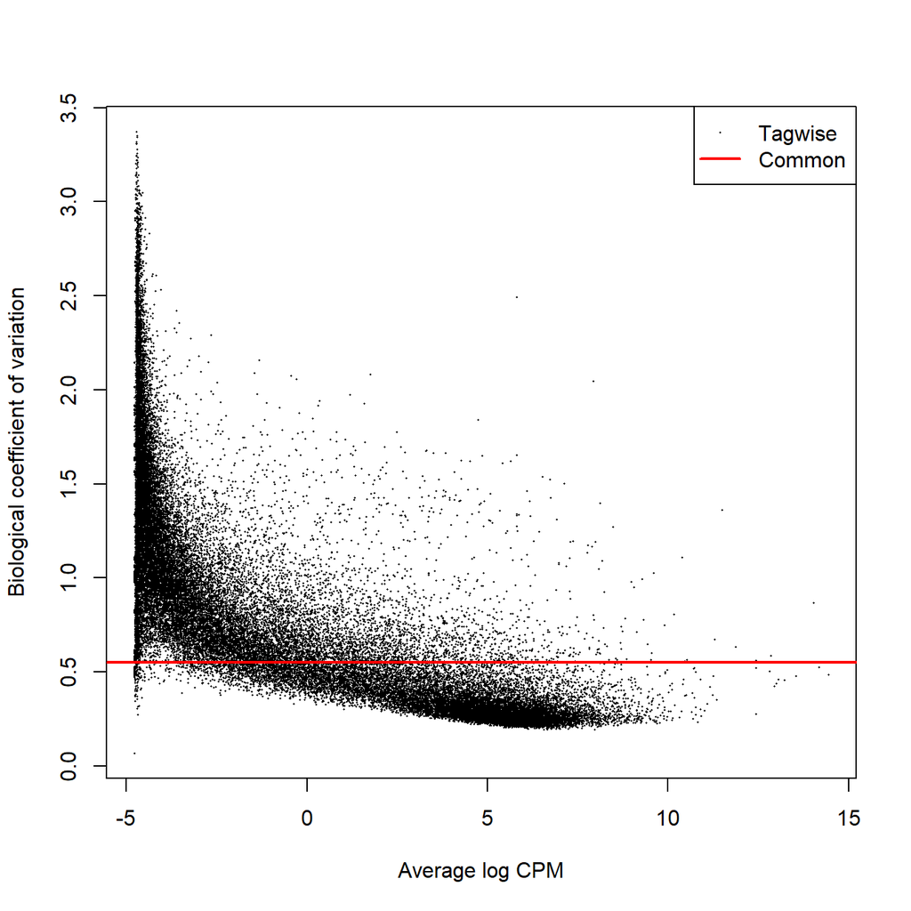

Diagrama que representa el coeficiente biológico de variación con respecto a la abundancia de genes

Una vez analizada la dispersión, podemos ver la expresión diferencial entre los distintos grupos.

```r
> exactEdgeR12 <- exactTest(DGEFiltered, pair = c(1, 2))
> exactEdgeR23 <- exactTest(DGEFiltered, pair = c(2, 3))
> exactEdgeR13 <- exactTest(DGEFiltered, pair = c(1, 3))
>
> resultEdgeR12 <- topTags(exactEdgeR12)
> resultEdgeR12
```

```
Comparison of groups:  NIT-ELI
                    logFC    logCPM       PValue          FDR
ENSG00000136573 -7.180261 4.1537257 5.360169e-19 1.659468e-14
ENSG00000156738 -7.982510 6.3209987 7.179338e-19 1.659468e-14
ENSG00000009790 -3.938390 4.4020062 2.373792e-18 3.657934e-14
ENSG00000177455 -7.454043 4.0853652 1.481851e-17 1.712612e-13
ENSG00000168081 -6.707998 0.1610882 2.313853e-17 2.139342e-13
ENSG00000253701 -8.730255 0.5424459 2.845128e-17 2.192124e-13
ENSG00000110777 -6.037538 4.9277342 4.411517e-17 2.913429e-13
ENSG00000205744 -2.850786 4.6996188 7.075680e-17 4.088770e-13
ENSG00000104894 -4.081733 5.4055077 8.575406e-17 4.404805e-13
ENSG00000247982 -3.903749 4.6793341 1.116766e-16 5.162696e-13
```

```r
> resultEdgeR23 <- topTags(exactEdgeR23)
> resultEdgeR23
```

```
Comparison of groups:  SFI-NIT
                   logFC     logCPM       PValue          FDR
ENSG00000211611 8.664479  2.0147358 1.670670e-09 5.034136e-05
ENSG00000254395 6.821592  0.3710304 2.314343e-09 5.034136e-05
ENSG00000211973 6.614879  5.7996074 3.359999e-09 5.034136e-05
ENSG00000211939 6.582627  2.5979389 4.355825e-09 5.034136e-05
ENSG00000211598 5.217734  5.6374487 9.991568e-09 5.307438e-05
ENSG00000211900 5.835525  2.9657980 1.004904e-08 5.307438e-05
ENSG00000211895 4.886245 10.3822072 1.057545e-08 5.307438e-05
ENSG00000211685 6.695387  3.1258138 1.173165e-08 5.307438e-05
ENSG00000211673 6.823708  4.9057917 1.188441e-08 5.307438e-05
ENSG00000231486 5.110774  2.1326328 1.217539e-08 5.307438e-05
```

```r
> resultEdgeR13 <- topTags(exactEdgeR13)
> resultEdgeR13
```

```
Comparison of groups:  SFI-ELI
                    logFC   logCPM       PValue          FDR
ENSG00000009790 -3.266193 4.402006 7.904510e-14 3.654176e-09
ENSG00000068831 -2.858334 5.809716 7.890343e-13 1.770348e-08
ENSG00000204282 -2.521523 3.864268 1.148856e-12 1.770348e-08
ENSG00000247982 -3.213860 4.679334 1.859460e-12 2.149024e-08
ENSG00000111913 -2.602845 4.512599 3.102877e-12 2.703217e-08
ENSG00000065357 -2.192464 5.779377 3.508469e-12 2.703217e-08
ENSG00000170006 -2.600735 2.556135 1.035446e-11 6.635154e-08
ENSG00000146285 -3.337412 2.473039 1.283724e-11 6.635154e-08
ENSG00000233355 -4.246032 1.802462 1.291752e-11 6.635154e-08
ENSG00000205056 -5.072784 2.153544 1.652945e-11 7.544928e-08
```

Los objetos *TopTags* obtenidos nos muestran 5 columnas para cada una de las 3 comparaciones realizadas: la primera muestra los identificadores de los genes, la segunda `logFC` es el logaritmo en base 2 del *fold change*, la tercera `logCPM` es la media del `log2` de las cuentas por millón para cada gen, la cuarta `PValue` es el p valor para la significancia estadística de este cambio, y la última, `FDR` es el p valor ajustado para test múltiple que controla los falsos positivos.

Para visualizar mejor estos resultados los representamos gráficamente:

### 3.3.1 Representación gráfica (*Smear plots*) de las tres comparaciones

#### 3.3.1.1 NIT vs ELI

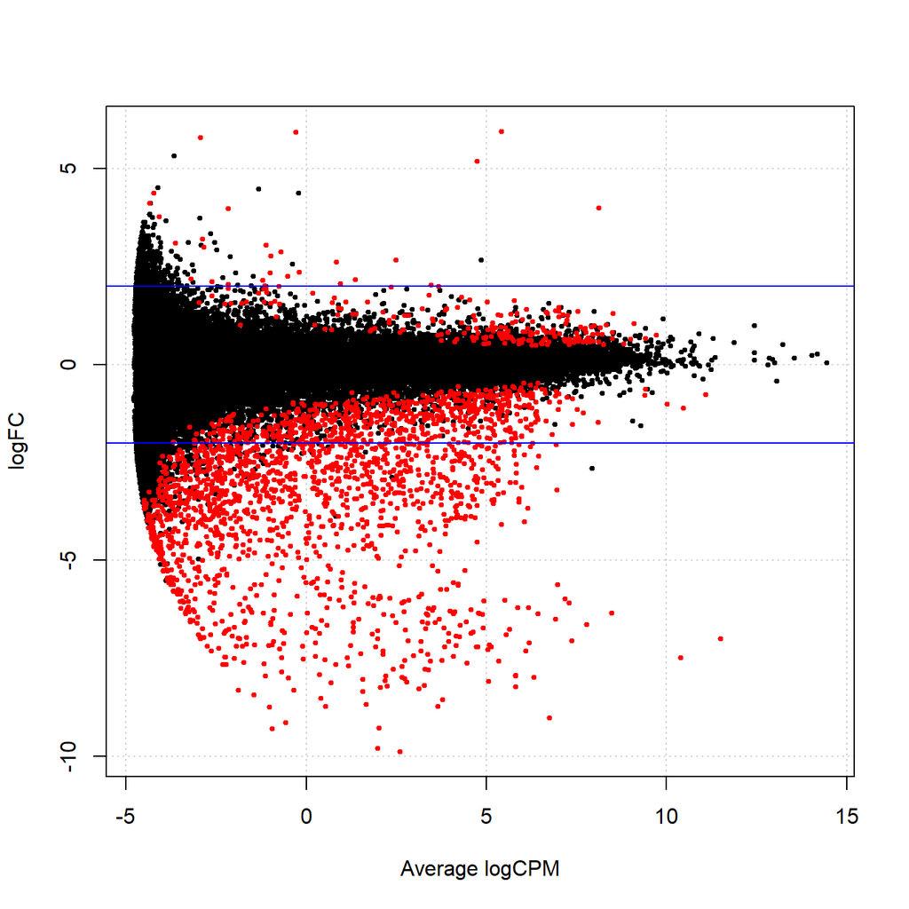

Representación gráfica de la expresión diferencial entre los grupos NIT y ELI

#### 3.3.1.2 SFI vs NIT

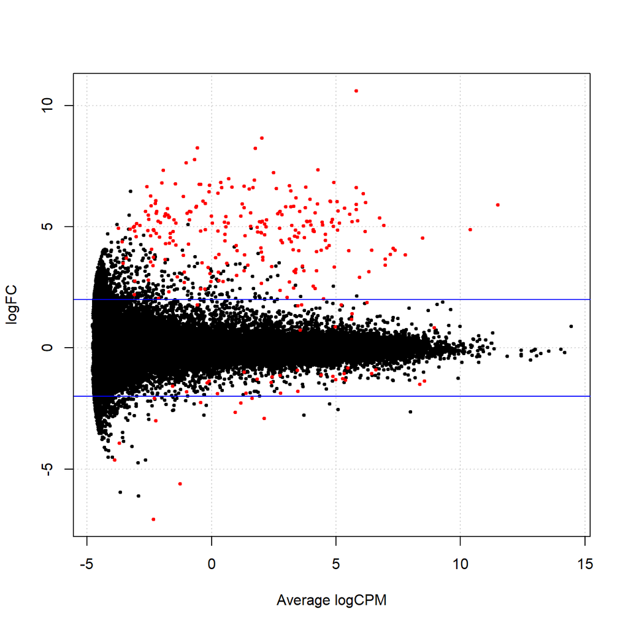

Representación gráfica de la expresión diferencial entre los grupos SFI y NIT

#### 3.3.1.3 SFI vs ELI

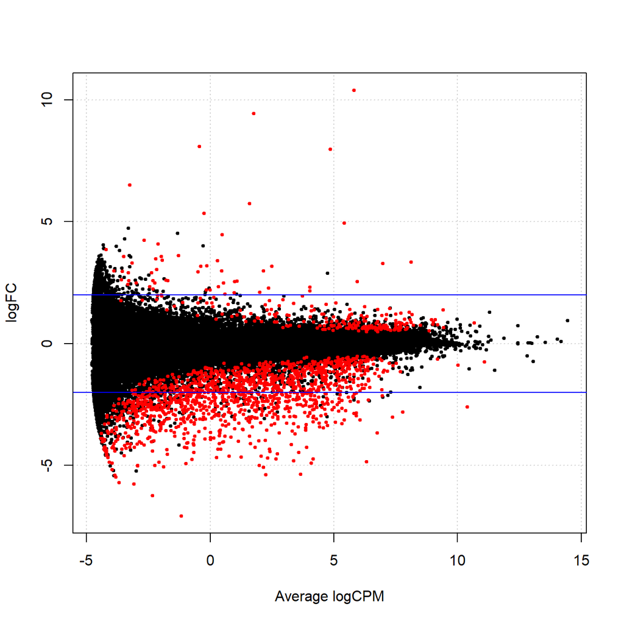

Representación gráfica de la expresión diferencial entre los grupos SFI y ELI

### 3.3.2 Volcano plots de las comparaciones entre grupos

#### 3.3.2.1 NIT vs ELI

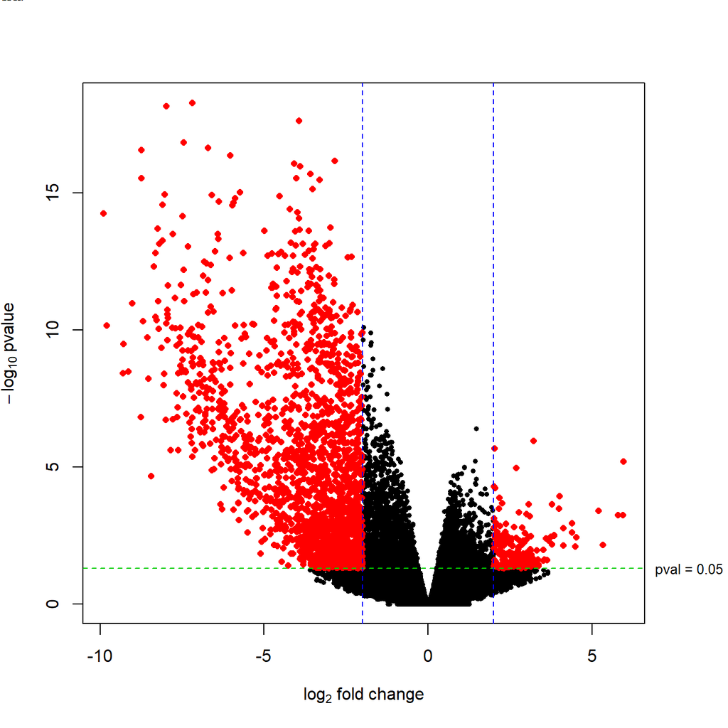

#### 3.3.2.2 SFI vs NIT

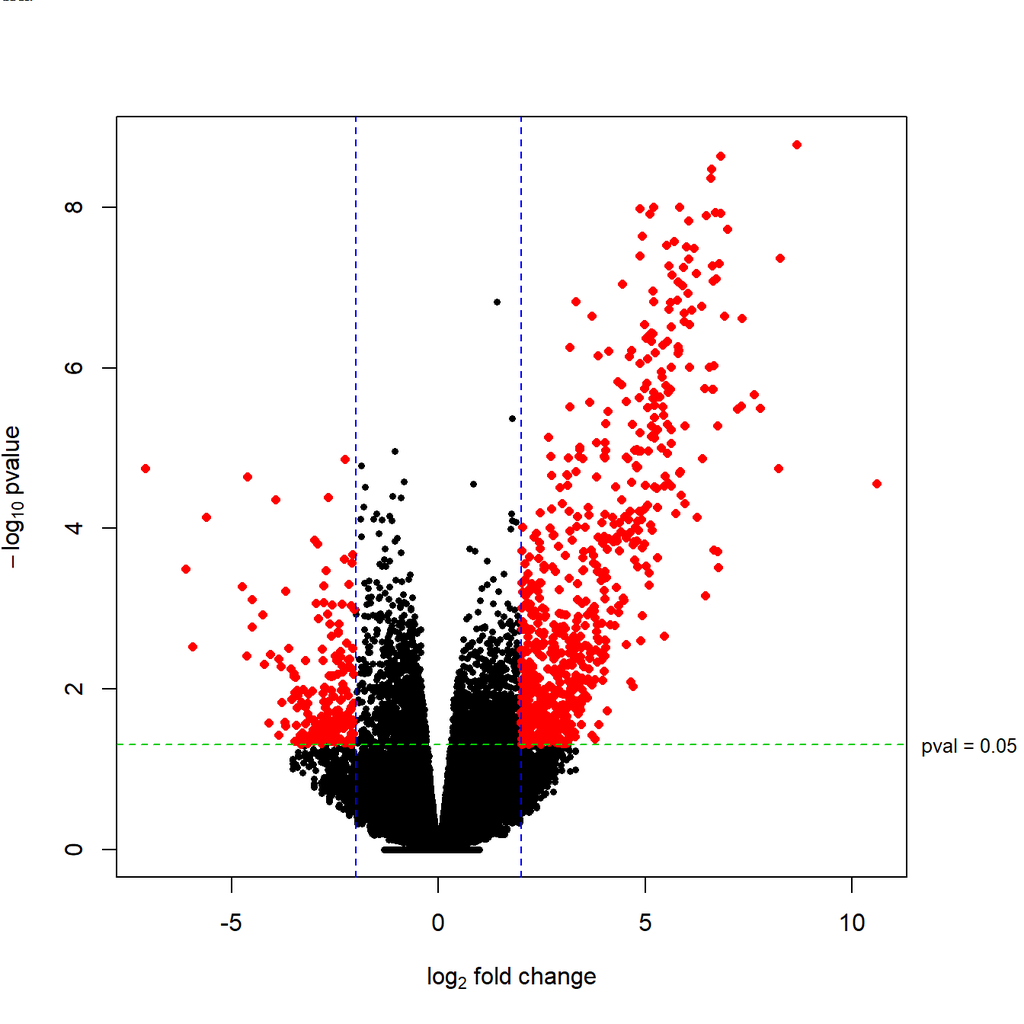

#### 3.3.2.3 SFI vs ELI

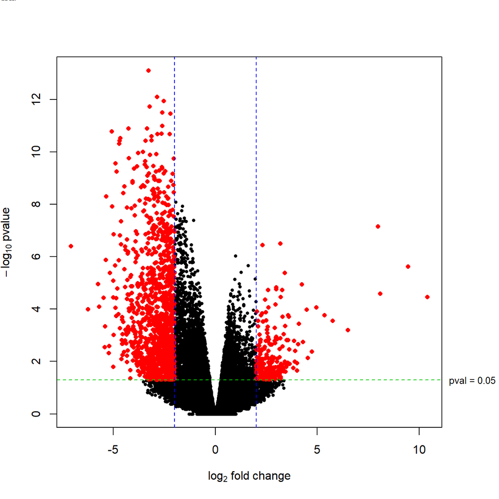

## 3.4 Anotación de los resultados

Utilizando el paquete `biomaRt` creamos una tabla para anotar nuestros genes:

```r
> library(biomaRt)
> my_ensemblIDs <- row.names(DGEFiltered[["pseudo.counts"]])
> ensembl <- useMart("ensembl", dataset = "hsapiens_gene_ensembl")
> anotationTable <- getBM(attributes = c("external_gene_name",
+     "ensembl_gene_id", "entrezgene_id", "go_id", "name_1006"),
+     filters = c("ensembl_gene_id"), values = my_ensemblIDs, mart = ensembl)
```

```r
> # Filtramos los genes que no tienen entrezgeneID
> DGEFiltered$anotation <- anotationTable[!is.na(anotationTable$entrezgene_id),
+     c("external_gene_name", "ensembl_gene_id", "entrezgene_id",
+         "go_id", "name_1006")]
> head(DGEFiltered$anotation)
```

|  | external_gene_name | ensembl_gene_id | entrezgene_id | go_id | name_1006 |
| --- | --- | --- | --- | --- | --- |
| 387 | PHLDA3 | ENSG00000174307 | 23612 | GO:0043065 | positive regulation of apoptotic process |
| 388 | PHLDA3 | ENSG00000174307 | 23612 | GO:1901981 | phosphatidylinositol phosphate binding |
| 389 | PHLDA3 | ENSG00000174307 | 23612 | GO:0005737 | cytoplasm |
| 390 | PHLDA3 | ENSG00000174307 | 23612 | GO:0016020 | membrane |
| 391 | PHLDA3 | ENSG00000174307 | 23612 | GO:0005886 | plasma membrane |
| 392 | PHLDA3 | ENSG00000174307 | 23612 | GO:0006915 | apoptotic process |

## 3.5 Busca de patrones de expresión y agrupación de las muestras (comparación entre las distintas comparaciones)

## 3.6 Análisis de significación biológica (“*Gene Enrichment Analysis*”)

# 4 Resultados

# 5 Discusión

# 6 Apéndice

# Bibliografía

Evans, Ciaran, Johanna Hardin, and Daniel M Stoebel. 2017. “Selecting Between-Sample Rna-Seq Normalization Methods from the Perspective of Their Assumptions.” *Briefings in Bioinformatics* 19 (5): 776–92. https://doi.org/10.1093/bib/bbx008.

“GTEx Portal.” n.d. https://www.gtexportal.org/home/.